# Multinomial Data (ELMR Chapter 7)

Biostat 200C

Author

Dr. Jin Zhou @ UCLA

Published

April 30, 2026

Display system information and load `tidyverse` and `faraway` packages

```r
library(tidyverse)
library(faraway)
```

`faraway` package contains the datasets in the ELMR book.

## 1 Multinomial logit model

- Multinomial regression is a natural extension of the binomial regression to the case when responses are multivariate counts. Let $Y_{ij}$ be the number of observations falling into category $j$ for batch $i$ and let $n_i = \sum_j Y_{ij}$ be the batch size. Then
  $$\mathbb{P}(Y_{i1} = y_{i1}, \ldots, Y_{iJ} = y_{iJ}) = \binom{n_i}{y_{i1} \cdots y_{iJ}} p_{i1}^{y_{i1}} \cdots p_{iJ}^{y_{iJ}}.$$
- We distinguish between **nominal** multinomial data where there is no natural order to the categories and **ordinal** multinomial data where there is an order. The **multinomial logit** model is indended for nominal data. It can be used for ordinal data, but the informtion about order will not be used.
- We use the same idea as the logistic regression.
  $$\eta_{ij} = \mathbf{x}_i^T \boldsymbol{\beta}_j = \log \frac{p_{ij}}{p_{i1}}, \quad j = 2,\ldots,J.$$
  We need to obey the constraint that $\sum_{i=1}^J p_{ij} = 1$ so it is convenient to declare one of the categories as the baseline say $j=1$. Then we set $p_{i1} = 1 - \sum_{j=2}^J p_{ij}$ and have
  $$p_{ij} = \frac{\exp(\eta_{ij})}{1 + \sum_{j=2}^J \exp(\eta_{ij})}.$$
- Suppose the length of $\mathbf{x}_i$ is $p$, then the multinomial-logit model consumes $p(J-1)$ parameters.
- We may estimate the parameters using MLE and the standard methods for inference.

### 1.1 1996 election data

- Consider an example of the 1996 American National Election Study. We consider only the education level and income group of the respondents. We will study how party identification of the respondent (Democrat, Independent or Republican) depends on predictors age, education level, and income.

```r
(nes96 <- as_tibble(nes96))
```

```
# A tibble: 944 × 10
   popul TVnews selfLR ClinLR DoleLR PID       age educ  income   vote
   <int>  <int> <ord>  <ord>  <ord>  <ord>   <int> <ord> <ord>    <fct>
 1     0      7 extCon extLib Con    strRep     36 HS    $3Kminus Dole
 2   190      1 sliLib sliLib sliCon weakDem    20 Coll  $3Kminus Clinton
 3    31      7 Lib    Lib    Con    weakDem    24 BAdeg $3Kminus Clinton
 4    83      4 sliLib Mod    sliCon weakDem    28 BAdeg $3Kminus Clinton
 5   640      7 sliCon Con    Mod    strDem     68 BAdeg $3Kminus Clinton
 6   110      3 sliLib Mod    Con    weakDem    21 Coll  $3Kminus Clinton
 7   100      7 sliCon Con    Mod    weakDem    77 Coll  $3Kminus Clinton
 8    31      1 sliCon Mod    sliCon indRep     21 Coll  $3Kminus Clinton
 9   180      7 Mod    Con    sliLib indind     31 Coll  $3Kminus Clinton
10  2800      0 sliLib sliLib extCon strDem     39 HS    $3Kminus Clinton
# ℹ 934 more rows
```

- Numerical summaries:

```r
summary(nes96)
```

```
     popul            TVnews         selfLR       ClinLR       DoleLR
 Min.   :   0.0   Min.   :0.000   extLib: 16   extLib:109   extLib: 13
 1st Qu.:   1.0   1st Qu.:1.000   Lib   :103   Lib   :317   Lib   : 31
 Median :  22.0   Median :3.000   sliLib:147   sliLib:236   sliLib: 43
 Mean   : 306.4   Mean   :3.728   Mod   :256   Mod   :160   Mod   : 87
 3rd Qu.: 110.0   3rd Qu.:7.000   sliCon:170   sliCon: 67   sliCon:195
 Max.   :7300.0   Max.   :7.000   Con   :218   Con   : 36   Con   :460
                                  extCon: 34   extCon: 19   extCon:115
      PID           age            educ           income         vote
 strDem :200   Min.   :19.00   MS    : 13   $60K-$75K:103   Clinton:551
 weakDem:180   1st Qu.:34.00   HSdrop: 52   $50K-$60K:100   Dole   :393
 indDem :108   Median :44.00   HS    :248   $30K-$35K: 70
 indind : 37   Mean   :47.04   Coll  :187   $25K-$30K: 68
 indRep : 94   3rd Qu.:58.00   CCdeg : 90   $105Kplus: 68
 weakRep:150   Max.   :91.00   BAdeg :227   $35K-$40K: 62
 strRep :175                   MAdeg :127   (Other)  :473
```

- The original variable `PID` (party identification) has ordered categories `strDem` (strong democratic), `weakDem` (weak democratic), `indDem` (independent democratic), `indind` (independent), `indRep` (independent republican), `weakRep` (weak Republican), and `strRep` (strong republican). In this analysis we only consider the coarsened categories: `Democratic`, `Independent`, and `Republican`.

```r
nes96 <- nes96 %>%
  mutate(sPID = recode(PID,
                       strDem  = "Democrat",
                       weakDem = "Democrat",
                       indDem  = "Independent",
                       indind  = "Independent",
                       indRep  = "Independent",
                       weakRep = "Republican",
                       strRep  = "Republican"))
summary(nes96$sPID)
```

```
   Democrat Independent  Republican
        380         239         325
```

- The income variable in the original data was an ordered factor with income ranges. We convert this to a numeric variable by taking the midpoint of each range.

```r
table(nes96$income)
```

```
  $3Kminus    $3K-$5K    $5K-$7K    $7K-$9K   $9K-$10K  $10K-$11K  $11K-$12K
        19         12         17         19         18         13         11
 $12K-$13K  $13K-$14K  $14K-$15K  $15K-$17K  $17K-$20K  $20K-$22K  $22K-$25K
        17         10         15         23         35         26         39
 $25K-$30K  $30K-$35K  $35K-$40K  $40K-$45K  $45K-$50K  $50K-$60K  $60K-$75K
        68         70         62         48         51        100        103
 $75K-$90K $90K-$105K  $105Kplus
        53         47         68
```

```r
inca <- c(1.5, 4, 6, 8, 9.5, 10.5, 11.5, 12.5, 13.5,
          14.5, 16, 18.5, 21, 23.5, 27.5, 32.5, 37.5,
          42.5, 47.5, 55, 67.5, 82.5, 97.5, 115)
nes96 <- nes96 %>%
  mutate(nincome = inca[unclass(income)])
summary(nes96$nincome)
```

```
   Min. 1st Qu.  Median    Mean 3rd Qu.    Max.
   1.50   23.50   37.50   46.58   67.50  115.00
```

- Graphical summaries.

How does party identification changes with education level?

```
# A tibble: 21 × 4
# Groups:   educ [7]
   educ   sPID            n   prop
   <ord>  <ord>       <int>  <dbl>
 1 MS     Democrat        9 0.692
 2 MS     Independent     3 0.231
 3 MS     Republican      1 0.0769
 4 HSdrop Democrat       29 0.558
 5 HSdrop Independent    14 0.269
 6 HSdrop Republican      9 0.173
 7 HS     Democrat      108 0.435
 8 HS     Independent    63 0.254
 9 HS     Republican     77 0.310
10 Coll   Democrat       74 0.396
# ℹ 11 more rows
```

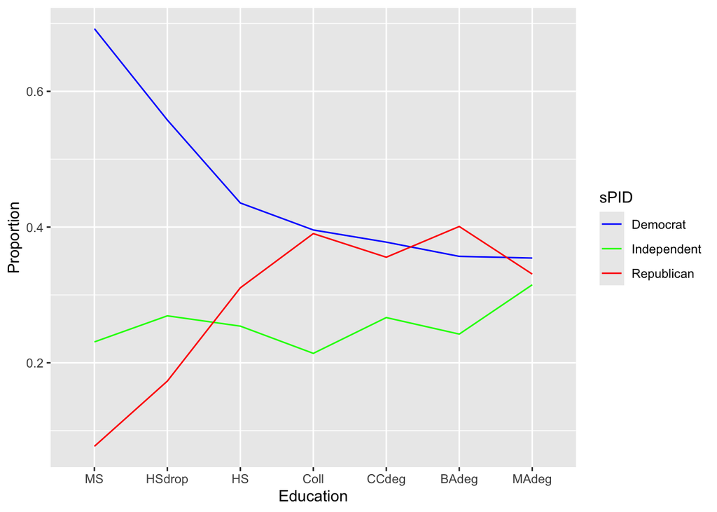

```r
nes96 %>%
  count(educ, sPID) %>%
  group_by(educ) %>%
  mutate(prop = prop.table(n)) %>%
  print(width = Inf) %>%
  ggplot() +
  geom_line(mapping = aes(x = educ, y = prop, group = sPID, color = sPID)) +
  scale_color_manual(values = c("blue", "green", "red")) +
  labs(x = "Education", y = "Proportion")
```

How does party identification changes with income level?

```
# A tibble: 72 × 4
# Groups:   income [24]
   income   sPID            n   prop
   <ord>    <ord>       <int>  <dbl>
 1 $3Kminus Democrat       13 0.684
 2 $3Kminus Independent     3 0.158
 3 $3Kminus Republican      3 0.158
 4 $3K-$5K  Democrat        7 0.583
 5 $3K-$5K  Independent     4 0.333
 6 $3K-$5K  Republican      1 0.0833
 7 $5K-$7K  Democrat        9 0.529
 8 $5K-$7K  Independent     3 0.176
 9 $5K-$7K  Republican      5 0.294
10 $7K-$9K  Democrat       11 0.579
# ℹ 62 more rows
```

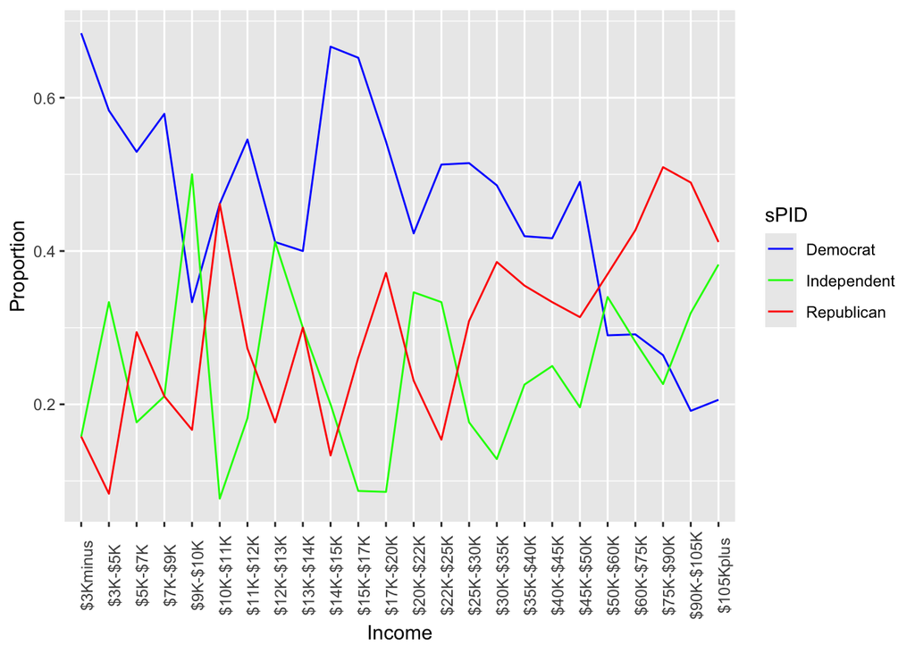

```r
nes96 %>%
  count(income, sPID) %>%
  group_by(income) %>%
  mutate(prop = prop.table(n)) %>%
  print(width = Inf) %>%
  ggplot() +
  geom_line(mapping = aes(x = income, y = prop, group = sPID, color = sPID)) +
  scale_color_manual(values = c("blue", "green", "red")) +
  labs(x = "Income", y = "Proportion") +
  theme(axis.text.x = element_text(angle = 90))
```

How does party identification changes with age?

```
# A tibble: 26 × 4
# Groups:   age_grp [9]
   age_grp sPID            n  prop
   <fct>   <ord>       <int> <dbl>
 1 (10,20] Democrat        3 0.333
 2 (10,20] Independent     2 0.222
 3 (10,20] Republican      4 0.444
 4 (20,30] Democrat       60 0.438
 5 (20,30] Independent    37 0.270
 6 (20,30] Republican     40 0.292
 7 (30,40] Democrat       87 0.348
 8 (30,40] Independent    65 0.26
 9 (30,40] Republican     98 0.392
10 (40,50] Democrat       89 0.441
# ℹ 16 more rows
```

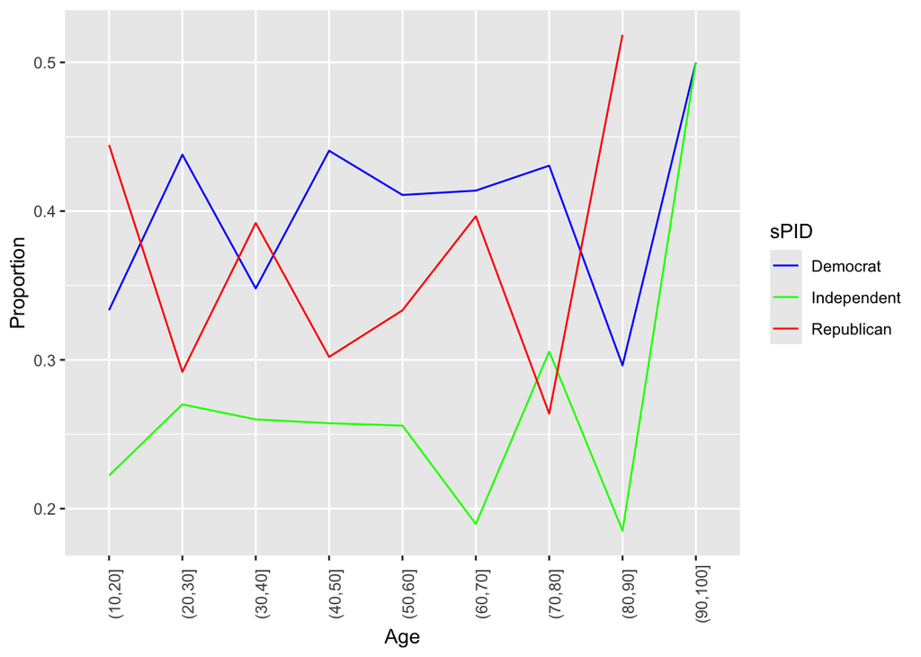

```r
nes96 %>%
  mutate(age_grp = cut(age, breaks = seq(from = 10, to = 100, by = 10))) %>%
  count(age_grp, sPID) %>%
  group_by(age_grp) %>%
  mutate(prop = prop.table(n)) %>%
  print(width = Inf) %>%
  ggplot() +
  geom_line(mapping = aes(x = age_grp, y = prop, group = sPID, color = sPID)) +
  scale_color_manual(values = c("blue", "green", "red")) +
  labs(x = "Age", y = "Proportion") +
  theme(axis.text.x = element_text(angle = 90))
```

### 1.2 Fit multinomial-logit

- To verify that the trends observed in these graphs are statistical significant, we need a formal model. The `multinom` function is avaible in the `nnet` package.

```r
library(nnet)
mmod <- multinom(sPID ~ age + educ + nincome, data = nes96)
summary(mmod)
```

```
Call:
multinom(formula = sPID ~ age + educ + nincome, data = nes96)

Coefficients:
            (Intercept)          age     educ.L     educ.Q    educ.C
Independent   -1.197260 0.0001534525 0.06351451 -0.1217038 0.1119542
Republican    -1.642656 0.0081943691 1.19413345 -1.2292869 0.1544575
                 educ^4     educ^5      educ^6    nincome
Independent -0.07657336  0.1360851  0.15427826 0.01623911
Republican  -0.02827297 -0.1221176 -0.03741389 0.01724679

Std. Errors:
            (Intercept)         age    educ.L    educ.Q    educ.C    educ^4
Independent   0.3265951 0.005374592 0.4571884 0.4142859 0.3498491 0.2883031
Republican    0.3312877 0.004902668 0.6502670 0.6041924 0.4866432 0.3605620
               educ^5    educ^6     nincome
Independent 0.2494706 0.2171578 0.003108585
Republican  0.2696036 0.2031859 0.002881745

Residual Deviance: 1968.333
AIC: 2004.333
```

- We can select which variables to include in the model based the AIC criterion using a stepwise search method.

```r
step(mmod)
```

```
Start:  AIC=2004.33
sPID ~ age + educ + nincome

trying - age
trying - educ
trying - nincome
          Df      AIC
- educ     6 1996.539
- age     16 2003.625
<none>    18 2004.333
- nincome 16 2045.911

Step:  AIC=1996.54
sPID ~ age + nincome

trying - age
trying - nincome
          Df      AIC
- age      4 1993.424
<none>     6 1996.539
- nincome  4 2048.850

Step:  AIC=1993.42
sPID ~ nincome

trying - nincome
          Df      AIC
<none>     4 1993.424
- nincome  2 2045.272
```

```
Call:
multinom(formula = sPID ~ nincome, data = nes96)

Coefficients:
            (Intercept)    nincome
Independent  -1.1749331 0.01608683
Republican   -0.9503591 0.01766457

Residual Deviance: 1985.424
AIC: 1993.424
```

- Or we can use the standard likelihood methods to derive a test to compare nested models. For example, we can fit a model with predictor `nincome` only and then compare the deviances.

```r
mmodi <- multinom(sPID ~ nincome, data = nes96)
deviance(mmodi) - deviance(mmod)
```

```
[1] 17.09176
```

```r
mmod$edf - mmodi$edf
```

```
[1] 14
```

```r
pchisq(deviance(mmodi) - deviance(mmod), mmod$edf - mmodi$edf, lower = F)
```

```
[1] 0.2513209
```

- To interpret the coefficients:

```r
summary(mmodi)
```

```
Call:
multinom(formula = sPID ~ nincome, data = nes96)

Coefficients:
            (Intercept)    nincome
Independent  -1.1749331 0.01608683
Republican   -0.9503591 0.01766457

Std. Errors:
            (Intercept)     nincome
Independent   0.1536103 0.002849738
Republican    0.1416859 0.002652532

Residual Deviance: 1985.424
AIC: 1993.424
```

- The intercept terms model the probabilities of party identification when income is zero.

```r
cc <- c(0, -1.17493, -0.95036)
exp(cc) / sum(exp(cc))
```

```
[1] 0.5898166 0.1821593 0.2280242
```

- The slope terms represent the log-odds of moving from the baseline category `Democrat` to `Independent` and `Republican` respectively for a unit change of $1000 in income.

```r
(pp <- predict(mmodi, data.frame(nincome = c(0, 1)), type = "probs"))
```

```
   Democrat Independent Republican
1 0.5898168   0.1821588  0.2280244
2 0.5857064   0.1838228  0.2304708
```

```r
log(pp[1, 1] * pp[2, 2] / (pp[1, 2] * pp[2, 1]))
```

```
[1] 0.01608683
```

```r
log(pp[1, 1] * pp[2, 3] / (pp[1, 3] * pp[2, 1]))
```

```
[1] 0.01766457
```

- We can obtain predicted values for specified values of income.

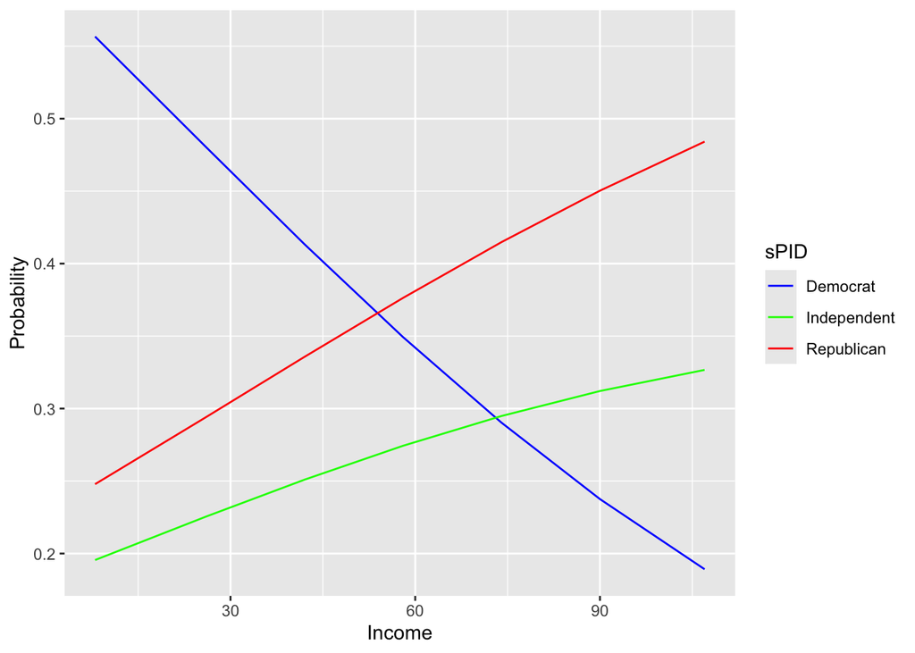

```r
il <- c(8, 26, 42, 58, 74, 90, 107)
predict(mmodi, data.frame(nincome = il), type = "probs") %>%
  as_tibble() %>%
  mutate(income = il) %>%
  pivot_longer(Democrat:Republican, names_to = "sPID", values_to = "prob") %>%
  ggplot() +
  geom_line(mapping = aes(x = income, y = prob, group = sPID, color = sPID)) +
  scale_color_manual(values = c("blue", "green", "red")) +
  labs(x = "Income", y = "Probability")
```

## 2 Hierarchical or nested responses

- Consider following data concerning live births with deformations of the central nervous system (CNS) in south Wales.

```r
(cns <- as_tibble(cns))
```

```
# A tibble: 16 × 7
   Area          NoCNS    An    Sp Other Water Work
   <fct>         <int> <int> <int> <int> <int> <fct>
 1 Cardiff        4091     5     9     5   110 NonManual
 2 Newport        1515     1     7     0   100 NonManual
 3 Swansea        2394     9     5     0    95 NonManual
 4 GlamorganE     3163     9    14     3    42 NonManual
 5 GlamorganW     1979     5    10     1    39 NonManual
 6 GlamorganC     4838    11    12     2   161 NonManual
 7 MonmouthV      2362     6     8     4    83 NonManual
 8 MonmouthOther  1604     3     6     0   122 NonManual
 9 Cardiff        9424    31    33    14   110 Manual
10 Newport        4610     3    15     6   100 Manual
11 Swansea        5526    19    30     4    95 Manual
12 GlamorganE    13217    55    71    19    42 Manual
13 GlamorganW     8195    30    44    10    39 Manual
14 GlamorganC     7803    25    28    12   161 Manual
15 MonmouthV      9962    36    37    13    83 Manual
16 MonmouthOther  3172     8    13     3   122 Manual
```

- Responses:
  - NoCNS: no CNS
  - An: anencephalus
  - Sp: sina bifida
  - Other: other malformations
- Predictors:
  - Water: water hardness
  - Work: type of work performed by the parents
- We might consider a multinomial response with four categories. However, we can see that most births suffer no malformation and so this category dominates the other three. It is better to consider this as a hierarchical response. Consider the multinomial likelihood for the $i$-th observation which is proportional to:
  $$p_{i1}^{y_{i1}} p_{i2}^{y_{i2}} p_{i3}^{y_{i3}} p_{i4}^{y_{i4}}$$
  Define $p_{ic} = p_{i2} + p_{i3} + p_{i4}$ which is the probability of a birth with some kind of CNS malformation. We can then write the likelihood as
  $$p_{i1}^{y_{i1}} p_{ic}^{y_{i2} + y_{i3} + y_{i4}} \times \left( \frac{p_{i2}}{p_{ic}} \right)^{y_{i2}} \left( \frac{p_{i3}}{p_{ic}} \right)^{y_{i3}} \left( \frac{p_{i4}}{p_{ic}} \right)^{y_{i4}}$$
  We can now separately develop a binomial model for whether malformation occurs and a multinomial model for the type of malformation.

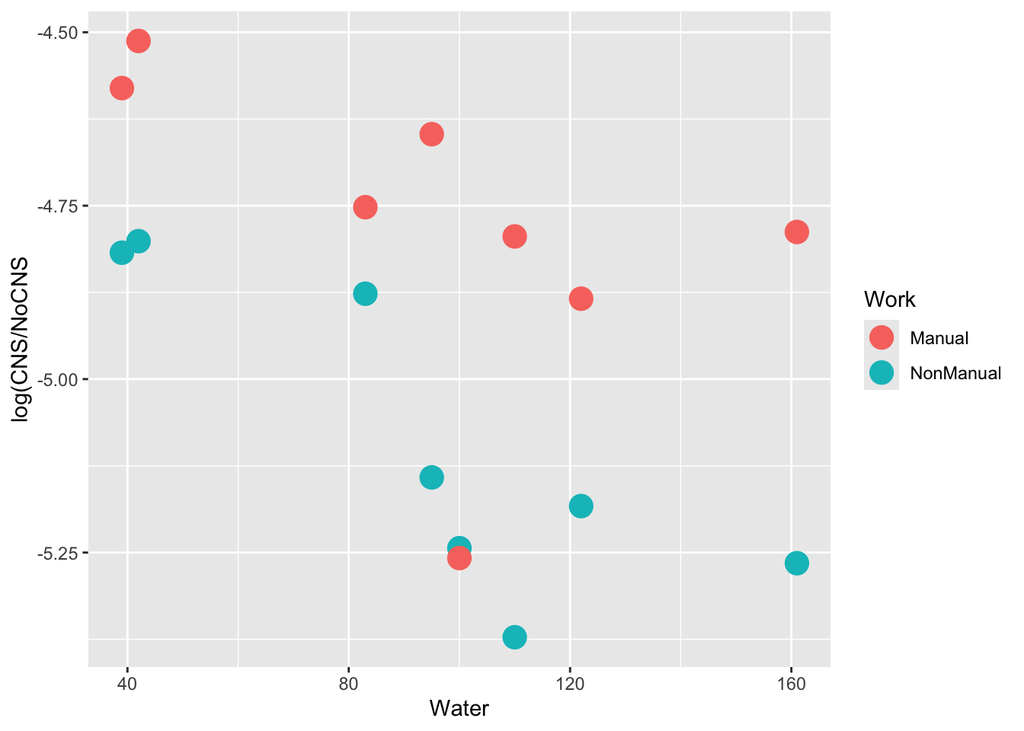

```r
cns %>%
  mutate(CNS = An + Sp + Other) %>%
  ggplot() +
  geom_point(mapping = aes(x = Water, y = log(CNS/NoCNS), color = Work), size = 5) +
  labs(x = "Water", y = "log(CNS/NoCNS")
```

We observe that the proportion of CNS births falls with increasing water hardness and is higher for manual workers.

```r
cns <- cns %>%
  mutate(CNS = An + Sp + Other)
binmodw <- glm(cbind(CNS, NoCNS) ~ Water + Work , cns, family = binomial)
binmoda <- glm(cbind(CNS,NoCNS) ~ Water, cns, family=binomial)
anova(binmodw, binmoda, test = "Chi")
```

```
Analysis of Deviance Table

Model 1: cbind(CNS, NoCNS) ~ Water + Work
Model 2: cbind(CNS, NoCNS) ~ Water
  Resid. Df Resid. Dev Df Deviance  Pr(>Chi)
1        13     12.363
2        14     25.359 -1  -12.996 0.0003122 ***
---
Signif. codes:  0 '***' 0.001 '**' 0.01 '*' 0.05 '.' 0.1 ' ' 1
```

```r
#halfnorm(hatvalues(binmodw))
#cns %>% slice(10)
```

```r
sumary(binmodw)
```

```
                Estimate Std. Error  z value  Pr(>|z|)
(Intercept)   -4.4325803  0.0897889 -49.3667 < 2.2e-16
Water         -0.0032644  0.0009684  -3.3709 0.0007492
WorkNonManual -0.3390577  0.0970943  -3.4920 0.0004793

n = 16 p = 3
Deviance = 12.36281 Null Deviance = 41.04749 (Difference = 28.68468)
```

The residual deviance is close to the degrees of freedom indicating a reasonable fit to the data. We see that since: exp(-0.339058)=0.7124411, births to nonmanual workers have a 29% lower chance of CNS malformation. Water hardness ranges from about 40 to 160. So a difference of 120 would decrease the odds of CNS malformation by about 32% (i.e., 1-exp(-0.0032644*120).

- Now consider a multinomial model for the three malformation types conditional on a malformation having occurred.

```r
cmmod <- multinom(cbind(An, Sp, Other) ~ Water + Work, cns)
```

- We find that neither predictor has much effect:

```r
nmod <- step(cmmod)
```

```
Start:  AIC=1383.52
cbind(An, Sp, Other) ~ Water + Work

trying - Water
trying - Work
        Df      AIC
- Water  4 1381.124
- Work   4 1381.161
<none>   6 1383.524

Step:  AIC=1381.12
cbind(An, Sp, Other) ~ Work

trying - Work
       Df      AIC
- Work  2 1378.455
<none>  4 1381.124

Step:  AIC=1378.45
cbind(An, Sp, Other) ~ 1
```

which leaves us with a null final model:

```r
nmod
```

```
Call:
multinom(formula = cbind(An, Sp, Other) ~ 1, data = cns)

Coefficients:
      (Intercept)
Sp      0.2896333
Other  -0.9808293

Residual Deviance: 1374.455
AIC: 1378.455
```

The fitted proportions are:

```r
cc <- c(0,0.28963,-0.98083)
names(cc) <- c("An","Sp","Other")
exp(cc)/sum(exp(cc))
```

```
       An        Sp     Other
0.3688767 0.4927946 0.1383287
```

So we find that water hardness and parents’ professions are related to the probability of a malformed birth, but that they have no effect on the type of malformation.

- If we fit a multinomial logit model to all four categories:

```r
mmmod <- multinom(cbind(NoCNS,An,Sp,Other) ~ Water + Work, cns)
sum_mmmod <- summary(mmmod)

z <- sum_mmmod$coefficients/sum_mmmod$standard.errors
p <- (1 - pnorm(abs(z), 0, 1))*2
p
```

```
      (Intercept)       Water WorkNonManual
An              0 0.066698463    0.02338251
Sp              0 0.001833413    0.07081474
Other           0 0.840985278    0.02347392
```

We find that both Water and Work are significant, but that the fact that they do not distinguish the type of malformation is not easily discovered from this model.

## 3 Ordinal multinomial responses

- Suppose we have $J$ ordered categories and $p_{ij} = \mathbb{P}(Y_i = j)$ for $j=1, \ldots, J$. For ordered responses, it is more convenient to work with the cumulative probabilities
  $$\gamma_{ij} = \mathbb{P}(Y_i \le j).$$
  Since $\gamma_{iJ}=1$, we only need to model $J-1$ cumulative probabilities.
- To link $\gamma$s to covariats $x$, we consider
  $$g(\gamma_{ij}) = \theta_j - \mathbf{x}_i^T \boldsymbol{\beta},$$
  where $\theta_j$ have to be non-decreasing in $j$ to honor the ordering. In other words, $\boldsymbol{\beta}$ has a uniform effect on the response categories and each category has its own intercept. Again we have at least 3 choices for the link function: logit, probit or cloglog.
- Latent variable interpretation.
  - Suppose that $Z_i$ is some unobserved continuous variable that might be thought of as the real underlying latent response. We only observe a discretized version of $Z_i$ in the form of $Y_i$ where $Y_i = j$ is observed if $\theta_{j−1} < Z_i ≤ \theta_j$. Further suppose that $Z_i − \beta^T x_i$ has distribution $F$, then:
    $$\gamma_{ij} = P(Y_i\leq j) = P(Z_i\leq \theta_j) = P(Z_i-\beta^Tx_i \leq \theta_j -\beta^Tx_i) = F(\theta_j-\beta^Tx_i)$$
  - Now if, for example, F follows the logistic distribution, where $F(x) = e^x/(1+e^x)$, then:

$$\gamma_{ij} = \frac{\text{exp}(\theta_j-\beta^Tx_i)}{1+\text{exp}(\theta_j-\beta^Tx_i)}$$
and so we would have a logit model for the cumulative probabilities $\gamma_{ij}$. Choosing the normal distribution for the latent variable leads to a probit model, while the choice of an extreme value distribution leads to the complementary log-log. This latent variable explanation for the model is displayed as the following figure.

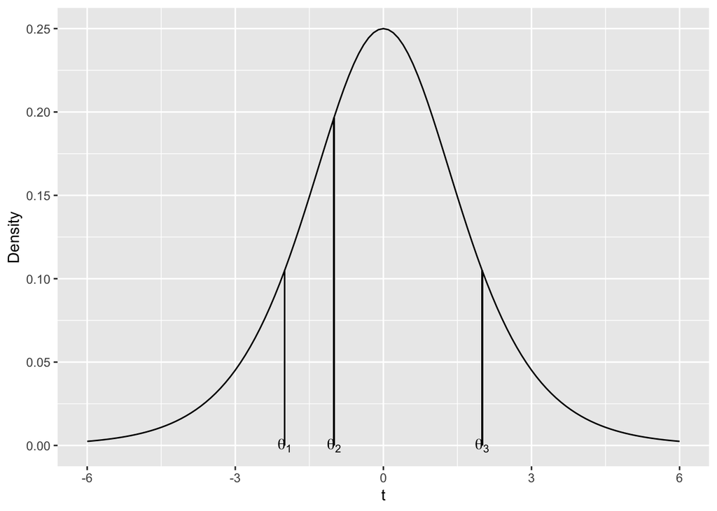

```r
theta <- c(-2, -1, 2)
tibble(t = seq(-6, 6, 0.1), pdf = dlogis(t, location = 0, scale = 1)) %>%
  ggplot() +
  geom_line(mapping = aes(x = t, y = pdf)) +
  geom_segment(mapping = aes(x = theta[1], y = 0, xend = theta[1], yend = dlogis(theta[1]))) +
  geom_segment(mapping = aes(x = theta[2], y = 0, xend = theta[2], yend = dlogis(theta[2]))) +
  geom_segment(mapping = aes(x = theta[3], y = 0, xend = theta[3], yend = dlogis(theta[3]))) +
  labs(x = "t", y = "Density") +
  annotate("text", x = theta[1], y = 0, label = expression(theta[1])) +
  annotate("text", x = theta[2], y = 0, label = expression(theta[2])) +
  annotate("text", x = theta[3], y = 0, label = expression(theta[3]))
```

### 3.1 Proportional odds model

- The logit link function dictates
  $$\log \frac{\gamma_{ij}}{1 - \gamma_{ij}} = \theta_j - \mathbf{x}_i^T \boldsymbol{\beta}, \quad j = 1,\ldots,J-1.$$
- The corresponding inverse link function is
  $$\gamma_{ij} = \mathbb{P}(Y_i \le j)= \frac{\exp (\theta_j - \mathbf{x}_i^T \boldsymbol{\beta})}{1 + \exp (\theta_j - \mathbf{x}_i^T \boldsymbol{\beta})}.$$

When $\beta_j > 0$, as $x_{ij}$ increases, $\gamma_{ij} = \mathbb{P}(Y_i \le j)$ decreases the same amount for all $j < J$, thus $Y_i$ is more likely to take the largest value $J$. This motivates the minus sign in the definition of the model since it allows easier interpretation of $\beta$.

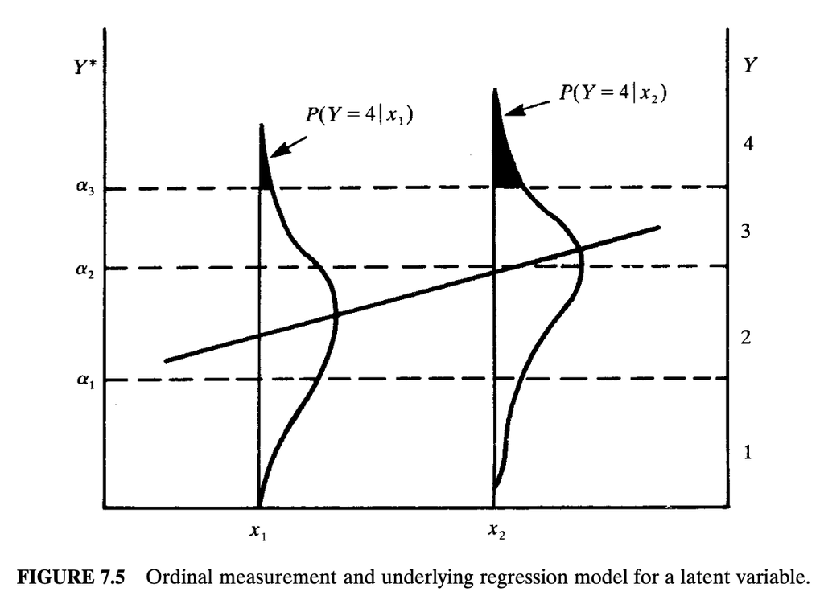

- It is called the **proportional odds model** because the relative odds for $y \le j$ comparing $\mathbf{x}_1$ and $\mathbf{x}_2$ are
  $$\left( \frac{\gamma_j(\mathbf{x}_1)}{1 - \gamma_j(\mathbf{x}_1)} \right) / \left( \frac{\gamma_j(\mathbf{x}_2)}{1 - \gamma_j(\mathbf{x}_2)} \right) = \exp (- (\mathbf{x}_1 - \mathbf{x}_2)^T \boldsymbol{\beta}),$$
  which do not dependent on $j$. Here $\gamma_j(\mathbf{x}_i) = \gamma_{ij}$.
- We can fit a proportional odds model using the `polr` function from the MASS library

```r
library(MASS)
pomod <- polr(sPID ~ age + educ + nincome, data = nes96)
summary(pomod)
```

```
Call:
polr(formula = sPID ~ age + educ + nincome, data = nes96)

Coefficients:
            Value Std. Error  t value
age      0.005775   0.003887  1.48581
educ.L   0.724087   0.384388  1.88374
educ.Q  -0.781361   0.351173 -2.22500
educ.C   0.040168   0.291762  0.13767
educ^4  -0.019925   0.232429 -0.08573
educ^5  -0.079413   0.191533 -0.41462
educ^6  -0.061104   0.157747 -0.38735
nincome  0.012739   0.002140  5.95187

Intercepts:
                       Value   Std. Error t value
Democrat|Independent    0.6449  0.2435     2.6479
Independent|Republican  1.7374  0.2493     6.9694

Residual Deviance: 1984.211
AIC: 2004.211
```

- Stepwise regression leads to a model with only one predictor `nincome`.

```r
pomodi <- step(pomod)
```

```
Start:  AIC=2004.21
sPID ~ age + educ + nincome

          Df    AIC
- educ     6 2002.8
<none>       2004.2
- age      1 2004.4
- nincome  1 2038.6

Step:  AIC=2002.83
sPID ~ age + nincome

          Df    AIC
- age      1 2001.4
<none>       2002.8
- nincome  1 2047.2

Step:  AIC=2001.36
sPID ~ nincome

          Df    AIC
<none>       2001.4
- nincome  1 2045.3
```

```r
summary(pomodi)
```

```
Call:
polr(formula = sPID ~ nincome, data = nes96)

Coefficients:
          Value Std. Error t value
nincome 0.01312   0.001971   6.657

Intercepts:
                       Value   Std. Error t value
Democrat|Independent    0.2091  0.1123     1.8627
Independent|Republican  1.2916  0.1201    10.7526

Residual Deviance: 1995.363
AIC: 2001.363
```

- Analysis of deviance also justifies the model with only `nincome`.

```r
c(deviance(pomodi), pomodi$edf)
```

```
[1] 1995.363    3.000
```

```r
c(deviance(pomod), pomod$edf)
```

```
[1] 1984.211   10.000
```

We see the proportional odds model is justifiable.

```r
pchisq(deviance(pomodi) - deviance(pomod),
       pomod$edf - pomodi$edf,
       lower.tail = FALSE)
```

```
[1] 0.1321517
```

- Interpretation of coefficients.
  - The odds of moving from `Democratic` to `Independent` or from `Independent` to `Republican` increases by a factor of

```r
    exp(pomodi$coef[1])
```

```
 nincome
1.013206
```

```
as income increases by one unit ($1000).
```

- For income of $0, the predicted probability of being a `Democrat` is

```r
    ilogit(pomodi$zeta[1])
```

```
Democrat|Independent
           0.5520865
```

```
and that of being an `Independent` is
```

```r
    ilogit(pomodi$zeta[2]) - ilogit(pomodi$zeta[1])
```

```
Independent|Republican
             0.2323241
```

```
and that of being a `Republican` is
```

```r
    1 - ilogit(pomodi$zeta[2])
```

```
Independent|Republican
             0.2155895
```

- The predicted probabilities of each category at each income level is

```r
l <- c(8, 26, 42, 58, 74, 90, 107)
predict(pomodi, data.frame(nincome = il), type = "probs")
```

```
   Democrat Independent Republican
1 0.5260129   0.2401191  0.2338679
2 0.4670450   0.2541588  0.2787962
3 0.4153410   0.2617693  0.3228897
4 0.3654362   0.2641882  0.3703756
5 0.3182635   0.2612285  0.4205080
6 0.2745456   0.2531189  0.4723355
7 0.2324161   0.2395468  0.5280371
```

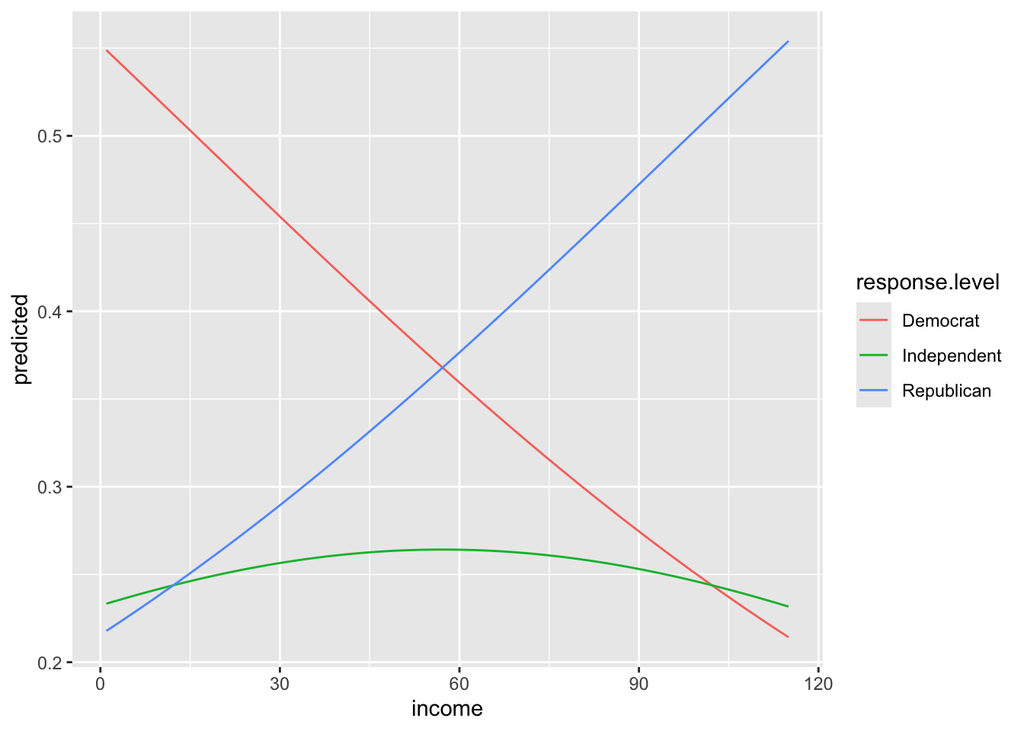

```r
library(ggeffects)
plot <- ggpredict(pomodi, "nincome")
ggplot(plot,
       aes(x = x, y = predicted, group = response.level, color = response.level)) +
  geom_line() +
  xlab("income")
```

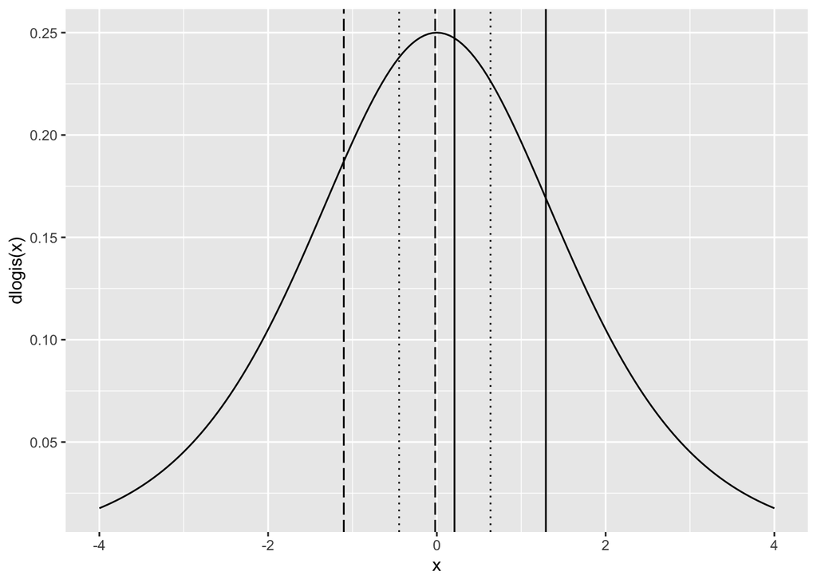

```r
tibble(x = seq(-4, 4, by = 0.05),
       y = dlogis(x)) %>%
  ggplot() +
  geom_line(aes(x = x, y = y)) +
  geom_vline(xintercept = c(0.209, 1.292)) +
  geom_vline(xintercept = c(0.209,1.292) - 50*0.013120, linetype = "dotted") +
  geom_vline(xintercept = c(0.209,1.292) -100*0.013120, linetype = "longdash") +
  labs(y = "dlogis(x)")
```

- Solid lines represent an income of $0, dotted lines are for $50,000 and dashed lines are for $100,000. The probability of being a Democrat is given by the area lying to the left of the leftmost of each pair of lines, while the probability of being a Republican is given by the area to the right of the rightmost of the pair. Independents are represented by the area in-between.

### 3.2 Ordered probit model

- If we use the probit link, then
  $$\Phi^{-1}(\gamma_j(\mathbf{x}_i)) = \theta_j - \mathbf{x}_i^T \boldsymbol{\beta}, \quad j=1,\ldots,J-1.$$

```r
opmod <- polr(sPID ~ nincome, method = "probit", data = nes96)
summary(opmod)
```

```
Call:
polr(formula = sPID ~ nincome, data = nes96, method = "probit")

Coefficients:
           Value Std. Error t value
nincome 0.008182   0.001208   6.775

Intercepts:
                       Value   Std. Error t value
Democrat|Independent    0.1284  0.0694     1.8510
Independent|Republican  0.7976  0.0722    11.0399

Residual Deviance: 1994.892
AIC: 2000.892
```

- The deviance is similar to the logit link, but the coefficients appear to be different. The predictions are similar.

```r
l <- c(8, 26, 42, 58, 74, 90, 107)
predict(opmod, data.frame(nincome = il), type = "probs")
```

```
   Democrat Independent Republican
1 0.5251020   0.2428478  0.2320502
2 0.4664030   0.2542673  0.2793298
3 0.4147945   0.2602623  0.3249432
4 0.3646178   0.2620370  0.3733452
5 0.3166610   0.2595041  0.4238349
6 0.2716037   0.2527879  0.4756084
7 0.2275119   0.2414351  0.5310530
```

### 3.3 Proportional hazards model

- Suppose we use the cloglog link
  $$\log (- \log (1 - \gamma_j(\mathbf{x}_i))) = \theta_j - \mathbf{x}_i^T \boldsymbol{\beta}.$$
- The **hazard** of category $j$ is the probability of falling in category $j$ given that your category is greater than $j$
  $$\text{Hazard}(j) = \mathbb{P}(Y_i = j \mid Y_i \ge j) = \frac{\mathbb{P}(Y_i = j)}{\mathbb{P}(Y_i \ge j)} = \frac{\gamma_{ij} - \gamma_{i,j-1}}{1 - \gamma_{i,j-1}}.$$
  The quantity $- \log \mathbb{P}(Y > j)$ is called the cumulative hazard function.
- Since
  $$\begin{eqnarray*}
  1 - \gamma_j(\mathbf{x}) &=& \mathbb{P}(Y > j) = e^{- e^{\theta_j - \mathbf{x}^T \boldsymbol{\beta}}},
  \end{eqnarray*}$$
  we have
  $$\begin{eqnarray*}
  \log \mathbb{P}(Y > j) = - e^{\theta_j - \mathbf{x}^T \boldsymbol{\beta}}
  \end{eqnarray*}$$
  and
  $$\frac{- \log \mathbb{P}(Y > j \mid \mathbf{x}_1)}{- \log \mathbb{P}(Y > j \mid \mathbf{x}_2)} = e^{(\mathbf{x}_2 - \mathbf{x}_1)^T \boldsymbol{\beta}}$$
  or
  $$\mathbb{P}(Y > j \mid \mathbf{x}_1) = [\mathbb{P}(Y > j \mid \mathbf{x}_2)]^{\exp (\mathbf{x}_2 - \mathbf{x}_1)^T \boldsymbol{\beta}}.$$
  It is called the **proportional hazards model** because the ratio of cumulative hazards does not depend on level $j$.

```r
polr(sPID ~ nincome, method = "cloglog", data = nes96)
```

```
Call:
polr(formula = sPID ~ nincome, data = nes96, method = "cloglog")

Coefficients:
    nincome
0.008271138

Intercepts:
  Democrat|Independent Independent|Republican
            -0.2866703              0.4564409

Residual Deviance: 2003.96
AIC: 2009.96
```

We see a relatively worse fit than proportional odds and ordered probit models.